# Is Dominic Thiem in a Slump?

An analysis of 'slumps' in men's professional tennis

By Abhay Patel

## Introduction

Tennis, like any other sport has legends. Whether you look at men's or women's tennis, there are those players that stand head and shoulders above all others. Roger Federer and Rafael Nadal stand as the best male players, where Serena Williams stands as the queen of tennis. However, these great players who capture the most important titles in tennis more than anyone are not immune to rough patches. A rising star in men's tennis is an Austrian player named Dominic Thiem, who won his first Grand Slam (quickly, Grand Slams are the 4 most important tournaments in tennis: the Australian Open, the French Open, Wimbledon, and the U.S. Open) in New York in September, 2020. After having an incredible few seasons, he seems to have broken to a new level during the 2020 season. However, Thiem has gotten off to a slow start in 2021 and has seemed to be in a bit of a rough spot. In this project, I will be diving into the data to analyze so called "slumps" in men's tennis. I will take a look at some of the career trajectories of retired players and the ongoing trajectories of some of the best active players to see if Dominic Thiem is indeed in a slump.

## Getting and Formatting the Data

The data for this project was acquired from [Jeff Sackmann's rich open source dataset](https://github.com/JeffSackmann/tennis_atp). As a quick sidenote, Sackmann has done some great work in tennis statistics and data collection, as well as analysis. You can find more data and a lot of in depth statistics (not just win rate but match-by-match breakdowns of each point played) at the [Tennis Abstract website](http://www.tennisabstract.com).

### Importing Libraries

We will begin by importing necessary libraries.

```python
import numpy as np
import pandas as pd
import matplotlib.pyplot as plt
import datetime
import warnings
import seaborn
import sklearn
from sklearn.linear_model import LinearRegression
from scipy.optimize import curve_fit
import statsmodels.api as sm

warnings.filterwarnings('ignore')
```

### Data Acquisition

For this project, we want to make sure we limit the data to what is relavent. To look at the players we want to look at while also not introducing too many confounding variables (such as changes in racket technology, player fitness, etc.) For these reasons, we will consider the years 1997 to 2021 (current). We choose 1997 as the start because that is the earliest year during which one of the players we are looking at (Marat Safin) began his professional career. We will now make dataframes for each of the years since the [dataset](https://github.com/JeffSackmann/tennis_atp) has separate csv files for each calendar year.

```python
# Array to hold the dataframes for each year
raw_dfs = []
# For convenience to read in the csv files
base_filename = './tennis_atp/atp_matches_'
end_filename = '.csv'

# Loops over each year from 1997 to 2021
for year in range(1997, 2022):
    # Creates the filename
    filename = base_filename + str(year) + end_filename
    # Reads the csv as a Pandas dataframe
    df = pd.read_csv(filename)
    # Adds current dataframe to the array
    raw_dfs.append(df)
```

### Data Cleaning/Formatting

Now, for each dataframe we have created, we only have the raw data. we want to first clean up the data we do have so that we can more easily start exploring the data. First, let's look at what each of the columns are and how many there are. Note that in this dataset, there is no missing data, so we do not have to deal with that.

```python
# Prints the column names and how many columns there are
raw_dfs[0].columns, raw_dfs[0].columns.shape
```

```
(Index(['tourney_id', 'tourney_name', 'surface', 'draw_size', 'tourney_level',
        'tourney_date', 'match_num', 'winner_id', 'winner_seed', 'winner_entry',
        'winner_name', 'winner_hand', 'winner_ht', 'winner_ioc', 'winner_age',
        'loser_id', 'loser_seed', 'loser_entry', 'loser_name', 'loser_hand',
        'loser_ht', 'loser_ioc', 'loser_age', 'score', 'best_of', 'round',
        'minutes', 'w_ace', 'w_df', 'w_svpt', 'w_1stIn', 'w_1stWon', 'w_2ndWon',
        'w_SvGms', 'w_bpSaved', 'w_bpFaced', 'l_ace', 'l_df', 'l_svpt',
        'l_1stIn', 'l_1stWon', 'l_2ndWon', 'l_SvGms', 'l_bpSaved', 'l_bpFaced',
        'winner_rank', 'winner_rank_points', 'loser_rank', 'loser_rank_points'],
       dtype='object'),
 (49,))
```

We can see that there are 49 columns. Many of them seem to not be of much use to us, so what we can do is create a new array to hold dataframes that contain the columns we do want to keep. Namely, we want to look at the `tourney_level` to see if it was a Grand Slam, Masters 1000, ATP 500, ATP 250, etc. We can also keep `tourney_name` for distinction later on as well as `tourney_date`. We want to keep `surface` as that can be an interesting variable to take into account since court surface is a large factor in the way the matches play out. We also want to look at `winner_name` to know who won and `winner_age` to keep track of where in that player's career we are. We also want to look at `loser_name` and `loser_age` for similar reasons. We can also keep all of the match statistics as they may be useful later in analysis.

```python
# Array to hold updated dataframes
updated_dfs = []
# List of unwanted columns
unwanted = ['tourney_id', 'draw_size', 'match_num', 'winner_id', 'winner_seed',
            'winner_entry', 'winner_hand', 'winner_ht', 'winner_ioc', 'loser_id',
            'loser_seed', 'loser_entry', 'loser_hand', 'loser_ht', 'loser_ioc']

# Loops over the previous array to get the updated dataframe
for df in raw_dfs:
    # Drops all of the unwanted columns and creates new dataframe
    new_df = df.drop(unwanted, axis=1)
    # Adds new dataframe to the array
    updated_dfs.append(new_df)
```

```python
updated_dfs[0].head()
```

|  | tourney_name | surface | tourney_level | tourney_date | winner_name | winner_age | loser_name | loser_age | score | best_of | ... | l_1stIn | l_1stWon | l_2ndWon | l_SvGms | l_bpSaved | l_bpFaced | winner_rank | winner_rank_points | loser_rank | loser_rank_points |
| --- | --- | --- | --- | --- | --- | --- | --- | --- | --- | --- | --- | --- | --- | --- | --- | --- | --- | --- | --- | --- | --- |
| 0 | Adelaide | Hard | A | 19961230 | Mikael Tillstrom | 24.821355 | Yevgeny Kafelnikov | 22.863792 | 6-2 6-2 | 3 | ... | 18.0 | 7.0 | 18.0 | 8.0 | 5.0 | 9.0 | 47.0 | 875.0 | 3.0 | 3564.0 |
| 1 | Adelaide | Hard | A | 19961230 | Byron Black | 27.233402 | Kenneth Carlsen | 23.704312 | 6-4 6-3 | 3 | ... | 25.0 | 21.0 | 9.0 | 9.0 | 1.0 | 3.0 | 44.0 | 886.0 | 73.0 | 636.0 |
| 2 | Adelaide | Hard | A | 19961230 | Patrick Rafter | 24.005476 | Jeff Salzenstein | 23.211499 | 6-4 6-3 | 3 | ... | 36.0 | 25.0 | 13.0 | 9.0 | 5.0 | 7.0 | 62.0 | 741.0 | 202.0 | 194.0 |
| 3 | Adelaide | Hard | A | 19961230 | Andrei Cherkasov | 26.491444 | Renzo Furlan | 26.622861 | 4-6 6-4 6-4 | 3 | ... | 51.0 | 40.0 | 17.0 | 15.0 | 6.0 | 10.0 | 133.0 | 339.0 | 40.0 | 993.0 |
| 4 | Adelaide | Hard | A | 19961230 | Todd Woodbridge | 25.746749 | Daniel Vacek | 25.749487 | 4-6 6-3 6-3 | 3 | ... | 41.0 | 31.0 | 22.0 | 14.0 | 2.0 | 5.0 | 36.0 | 1039.0 | 71.0 | 661.0 |

5 rows × 34 columns

```python
updated_dfs[0].columns.shape
```

```
(34,)
```

The next thing we want to do is get rid of a lot of the rows. We are only looking at a select group of players, so we want to go through all of the dataframes and keep the rows containing the names of target players. That is, we want to go through each dataframe and keep the rows where `winner_name` or `loser_name` is equal to the target player's name.

```python
# Array to hold final dataframes
dfs_mat = []
# List of target players
players = ['Dominic Thiem', 'Rafael Nadal', 'Roger Federer', 'Novak Djokovic',
           'Andy Murray', 'Andy Roddick', 'Alexander Zverev', 'Stefanos Tsitsipas',
           'Juan Martin del Potro', 'Marin Cilic', 'Lleyton Hewitt', 'Marat Safin',
           'Daniil Medvedev']

# Loops over previous array to get updated dataframe
for df in updated_dfs:
    # Creates array to hold dataframes for each player
    curr_year_dfs = []
    # Loops over each player
    for player in players:
        # Gets the rows where the winner or loser is the player
        tmp = df[(df['winner_name'] == player) | (df['loser_name'] == player)]
        # Adds this dataframe to the list of dataframes for the current year
        curr_year_dfs.append(tmp)
    # Adds the list of dataframes for each player to dfs
    dfs_mat.append(curr_year_dfs)
```

Now we have `dfs` as a matrix that has data for 25 years (from 1997-2021) and for 13 different players. This is split into separate dataframes, so there is a separate dataframe per player per year. We can make this neater by only having dataframes by player. This way, we can much more easily look at career trajectories as well as any other analysis we want to do.

```python
# Array to hold list of individual dataframes per player
player_dfs_tmp = []
# Array to hold dataframes per player
dfs = []

# Loops over the players
for i in range(13):
    # Creates array holding all dataframes by year
    curr_dfs = []
    # Loops over years
    for j in range(25):
        # Adds dataframe for player i during year j to array
        curr_dfs.append(dfs_mat[j][i])
    # Adds array of dataframes to matrix
    player_dfs_tmp.append(curr_dfs)

# Loops and uses Pandas concat function to create 1 dataframe for each player
for arr in player_dfs_tmp:
    tmp = pd.concat(arr)
    dfs.append(tmp)
```

Great! Now we have dataframes for each player showing their whole career (for players that are still active it is their total career from year turned pro to current). Just to see an example, let's look at the dataframe for Dominic Thiem.

```python
dfs[0].head()
```

|  | tourney_name | surface | tourney_level | tourney_date | winner_name | winner_age | loser_name | loser_age | score | best_of | ... | l_1stIn | l_1stWon | l_2ndWon | l_SvGms | l_bpSaved | l_bpFaced | winner_rank | winner_rank_points | loser_rank | loser_rank_points |
| --- | --- | --- | --- | --- | --- | --- | --- | --- | --- | --- | --- | --- | --- | --- | --- | --- | --- | --- | --- | --- | --- |
| 2119 | Kitzbuhel | Clay | A | 20110731 | Daniel Gimeno Traver | 25.982204 | Dominic Thiem | 17.908282 | 6-4 6-2 | 3 | ... | 19.0 | 15.0 | 12.0 | 9.0 | 3.0 | 7.0 | 80.0 | 655.0 | 918.0 | 10.0 |
| 2611 | Bangkok | Hard | A | 20110926 | Jarkko Nieminen | 30.176591 | Dominic Thiem | 18.061602 | 6-1 4-6 7-5 | 3 | ... | 42.0 | 28.0 | 19.0 | 14.0 | 2.0 | 7.0 | 50.0 | 851.0 | 1848.0 | 1.0 |
| 2861 | Vienna | Hard | A | 20111024 | Dominic Thiem | 18.138261 | Thomas Muster | 44.060233 | 6-2 6-3 | 3 | ... | 40.0 | 24.0 | 5.0 | 9.0 | 1.0 | 6.0 | 1890.0 | 1.0 | 1078.0 | 6.0 |
| 2872 | Vienna | Hard | A | 20111024 | Steve Darcis | 27.613963 | Dominic Thiem | 18.138261 | 6-2 6-2 | 3 | ... | 26.0 | 20.0 | 9.0 | 8.0 | 5.0 | 9.0 | 95.0 | 568.0 | 1890.0 | 1.0 |
| 2087 | Kitzbuhel | Clay | A | 20120722 | Martin Klizan | 23.033539 | Dominic Thiem | 18.885695 | 6-1 3-6 7-5 | 3 | ... | 48.0 | 36.0 | 20.0 | 14.0 | 5.0 | 9.0 | 62.0 | 773.0 | 442.0 | 79.0 |

5 rows × 34 columns

```python
dfs[0].tail()
```

|  | tourney_name | surface | tourney_level | tourney_date | winner_name | winner_age | loser_name | loser_age | score | best_of | ... | l_1stIn | l_1stWon | l_2ndWon | l_SvGms | l_bpSaved | l_bpFaced | winner_rank | winner_rank_points | loser_rank | loser_rank_points |
| --- | --- | --- | --- | --- | --- | --- | --- | --- | --- | --- | --- | --- | --- | --- | --- | --- | --- | --- | --- | --- | --- |
| 591 | Dubai | Hard | A | 20210315 | Lloyd Harris | 24.052019 | Dominic Thiem | 27.529090 | 6-3 6-4 | 3 | ... | 26.0 | 21.0 | 14.0 | 9.0 | 2.0 | 4.0 | 81.0 | 885.0 | 4.0 | 8625.0 |
| 954 | Madrid Masters | Clay | M | 20210503 | Alexander Zverev | 24.035592 | Dominic Thiem | 27.663244 | 6-3 6-4 | 3 | ... | 37.0 | 23.0 | 18.0 | 9.0 | 8.0 | 11.0 | 6.0 | 6125.0 | 4.0 | 8365.0 |
| 957 | Madrid Masters | Clay | M | 20210503 | Dominic Thiem | 27.663244 | John Isner | 36.019165 | 3-6 6-3 6-4 | 3 | ... | 47.0 | 36.0 | 16.0 | 14.0 | 2.0 | 4.0 | 4.0 | 8365.0 | 39.0 | 1550.0 |
| 962 | Madrid Masters | Clay | M | 20210503 | Dominic Thiem | 27.663244 | Alex De Minaur | 22.206708 | 7-6(7) 6-4 | 3 | ... | 46.0 | 32.0 | 11.0 | 11.0 | 6.0 | 9.0 | 4.0 | 8365.0 | 24.0 | 2235.0 |
| 972 | Madrid Masters | Clay | M | 20210503 | Dominic Thiem | 27.663244 | Marcos Giron | 27.775496 | 6-1 6-3 | 3 | ... | 25.0 | 16.0 | 8.0 | 8.0 | 5.0 | 9.0 | 4.0 | 8365.0 | 91.0 | 847.0 |

5 rows × 34 columns

Much of what we want to do will be observing patterns over time, so we want to slightly manipulate the `tourney_date` column to be more useful to us. We can split up the data into the year and the month so that we can plot these better. So for each of the dataframes we have created, we want to create a few new columns. Namely, we want to create `year`, `date_career` (which is the date but where the year represents the number of years that player has been pro), `c_win` (which is cumulative wins) and `c_loss` (which is cumulative losses). We also want to use the `c_win` and `c_loss` to add a column with the win rate, which we will call `win_rate`. We will also create a `date` column holding the datetime object for convenience later on.

```python
# First loop over and reset index for each dataframe
for df in dfs:
    # Resets index
    df.reset_index(inplace=True)
    # Drops the new index column
    df.drop('index', axis=1, inplace=True)
```

```python
# Index to keep track of player
player_ind = 0
# Loop over all dfs
for df in dfs:
    # Sorts by date to begin with
    df.sort_values(by=['tourney_date'], inplace=True)
    # Set arrays to be used for creating new columns
    year = []
    c_win = []
    c_loss = []
    date = []
    # Set counters for win/loss to zero
    win_counter = 0
    loss_counter = 0
    # Loop over all rows in dataframe
    for row in df.iterrows():
        # Extracts the year from the tourney_date
        year.append(int(str(row[1]['tourney_date'])[0:4]))
        # Converts to datetime object
        date.append(datetime.datetime.strptime(str(row[1]['tourney_date']), '%Y%m%d').date())
        # Checks if current player won or lost the match
        if row[1]['winner_name'] == players[player_ind]:
            win_counter += 1
        else:
            loss_counter += 1
        # Updates cumulative win/loss lists
        c_win.append(win_counter)
        c_loss.append(loss_counter)
    # Gets the year that current player started their career
    start_year = min(year)
    # Creates array for the current years into career for current player
    year_career = np.asarray(year) - start_year
    # Creates array for win rate
    win_rate = np.asarray(c_win) / (np.asarray(c_win) + np.asarray(c_loss))
    # Creates new columns in dataframe
    df['year'] = year
    df['date'] = date
    df['year_career'] = year_career
    df['c_win'] = c_win
    df['c_loss'] = c_loss
    df['win_rate'] = win_rate
    # Increments player index
    player_ind += 1
```

```python
dfs[0].head(10)
```

|  | tourney_name | surface | tourney_level | tourney_date | winner_name | winner_age | loser_name | loser_age | score | best_of | ... | winner_rank | winner_rank_points | loser_rank | loser_rank_points | year | date | year_career | c_win | c_loss | win_rate |
| --- | --- | --- | --- | --- | --- | --- | --- | --- | --- | --- | --- | --- | --- | --- | --- | --- | --- | --- | --- | --- | --- |
| 0 | Kitzbuhel | Clay | A | 20110731 | Daniel Gimeno Traver | 25.982204 | Dominic Thiem | 17.908282 | 6-4 6-2 | 3 | ... | 80.0 | 655.0 | 918.0 | 10.0 | 2011 | 2011-07-31 | 0 | 0 | 1 | 0.000000 |
| 1 | Bangkok | Hard | A | 20110926 | Jarkko Nieminen | 30.176591 | Dominic Thiem | 18.061602 | 6-1 4-6 7-5 | 3 | ... | 50.0 | 851.0 | 1848.0 | 1.0 | 2011 | 2011-09-26 | 0 | 0 | 2 | 0.000000 |
| 2 | Vienna | Hard | A | 20111024 | Dominic Thiem | 18.138261 | Thomas Muster | 44.060233 | 6-2 6-3 | 3 | ... | 1890.0 | 1.0 | 1078.0 | 6.0 | 2011 | 2011-10-24 | 0 | 1 | 2 | 0.333333 |
| 3 | Vienna | Hard | A | 20111024 | Steve Darcis | 27.613963 | Dominic Thiem | 18.138261 | 6-2 6-2 | 3 | ... | 95.0 | 568.0 | 1890.0 | 1.0 | 2011 | 2011-10-24 | 0 | 1 | 3 | 0.250000 |
| 4 | Kitzbuhel | Clay | A | 20120722 | Martin Klizan | 23.033539 | Dominic Thiem | 18.885695 | 6-1 3-6 7-5 | 3 | ... | 62.0 | 773.0 | 442.0 | 79.0 | 2012 | 2012-07-22 | 1 | 1 | 4 | 0.200000 |
| 5 | Vienna | Hard | A | 20121015 | Dominic Thiem | 19.115674 | Lukas Lacko | 24.950034 | 7-6(3) 6-3 | 3 | ... | 394.0 | 104.0 | 51.0 | 800.0 | 2012 | 2012-10-15 | 1 | 2 | 4 | 0.333333 |
| 6 | Vienna | Hard | A | 20121015 | Marinko Matosevic | 27.186858 | Dominic Thiem | 19.115674 | 6-3 7-6(5) | 3 | ... | 55.0 | 763.0 | 394.0 | 104.0 | 2012 | 2012-10-15 | 1 | 2 | 5 | 0.285714 |
| 7 | Kitzbuhel | Clay | A | 20130728 | Dominic Thiem | 19.901437 | Andrey Kuznetsov | 22.431211 | 6-2 7-5 | 3 | ... | 268.0 | 167.0 | 82.0 | 625.0 | 2013 | 2013-07-28 | 2 | 3 | 5 | 0.375000 |
| 8 | Kitzbuhel | Clay | A | 20130728 | Dominic Thiem | 19.901437 | Jurgen Melzer | 32.186174 | 7-5 6-3 | 3 | ... | 268.0 | 167.0 | 34.0 | 1220.0 | 2013 | 2013-07-28 | 2 | 4 | 5 | 0.444444 |
| 9 | Kitzbuhel | Clay | A | 20130728 | Albert Montanes | 32.670773 | Dominic Thiem | 19.901437 | 6-4 6-3 | 3 | ... | 45.0 | 910.0 | 268.0 | 167.0 | 2013 | 2013-07-28 | 2 | 4 | 6 | 0.400000 |

10 rows × 40 columns

## Exploring the Data

Now that we have the data properly formatted and have added the columns that we would like to look at, let's plot various features from the dataset to begin to understand the data. We are looking to discover any patterns or trends that we can use to gain a better understanding of the data. Keeping in mind that we are trying to answer the question "is Dominic Thiem in a slump?", we should begin by plotting a few key things:

- We can also plot the running total of wins over time across the careers of players.
- Similarly, we can plot the running total of losses over time across the careers of players.
- It would be a good idea to plot win rate over time to see if we can observe any general trends across the careers of various players.

### Data Visualization

Let's start plotting some of the interesting features. We will start by plotting wins over time. We have 13 players that we are looking at, so we will color code each player's line.

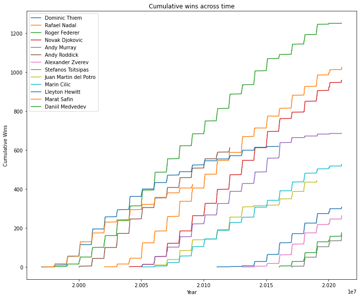

```python
# Creates figure
plt.figure(figsize=(12,10))
# Sets title and axis labels
plt.title('Cumulative wins across time')
plt.xlabel('Year')
plt.ylabel('Cumulative Wins')
# Plots a line per player
for i in range(13):
    plt.plot(dfs[i]['tourney_date'], dfs[i]['c_win'], label=players[i])
# Displays the legend
plt.legend()
plt.show()
```

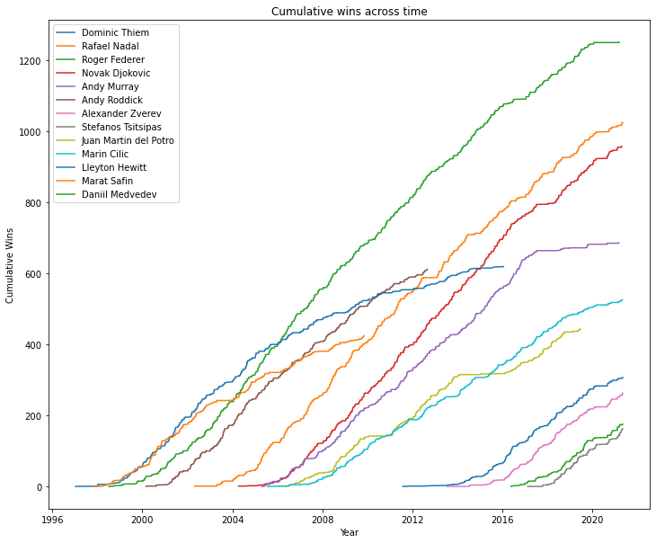

```python
# Creates figure
plt.figure(figsize=(12,10))
# Sets title and axis labels
plt.title('Cumulative wins across time')
plt.xlabel('Year')
plt.ylabel('Cumulative Wins')
# Plots a line per player
for i in range(13):
    plt.plot(dfs[i]['date'], dfs[i]['c_win'], label=players[i])
# Displays the legend
plt.legend()
plt.show()
```

From the plots above, we can see that using the `date` column yields smoother lines, so we will continue to use this column for the x-axis. We can make some observations from the above plots. Firstly, we can clearly see that Roger Federer stands far above the rest of the competition when it comes to total career wins. However, in terms of career trajectory, we can see that some of the players seem to have plateaus. This is indicative of an extended period of time without a win. For example, we can see a fairly long plateau in the purple line representing Andy Murray's career. The plateau begins around 2017, which is explainable. Murray had been dealing with injuries, and at this time his career took a bit of a tragic turn. He had to go through multiple hip surgeries that even caused him to retire from professional tennis for a period of time in 2018. He made a return to the professional tour, so we can see that there are a few more wins that represent the wins he has gotten since he returned to tour. Similarly, there is a plateau at the time of Juan Martin del Porto's injury period (from about 2014-2016), and Nadal's injury (which sidelined him from the tour for 7 months from 2012-2013). However, these plots don't really show much about slumps. There are historic slumps that are well known but do not show up in any way in the above plots. The above plot is more indicative of longer periods of injury. Let's look at some other features to see if we can gain new understanding of the data.

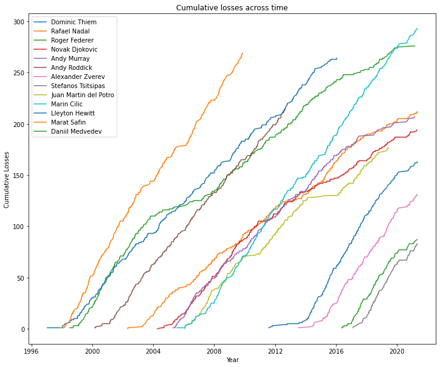

```python
# Creates figure
plt.figure(figsize=(12,10))
# Sets title and axis labels
plt.title('Cumulative losses across time')
plt.xlabel('Year')
plt.ylabel('Cumulative Losses')
# Plots a line per player
for i in range(13):
    plt.plot(dfs[i]['date'], dfs[i]['c_loss'], label=players[i])
# Displays the legend
plt.legend()
plt.show()
```

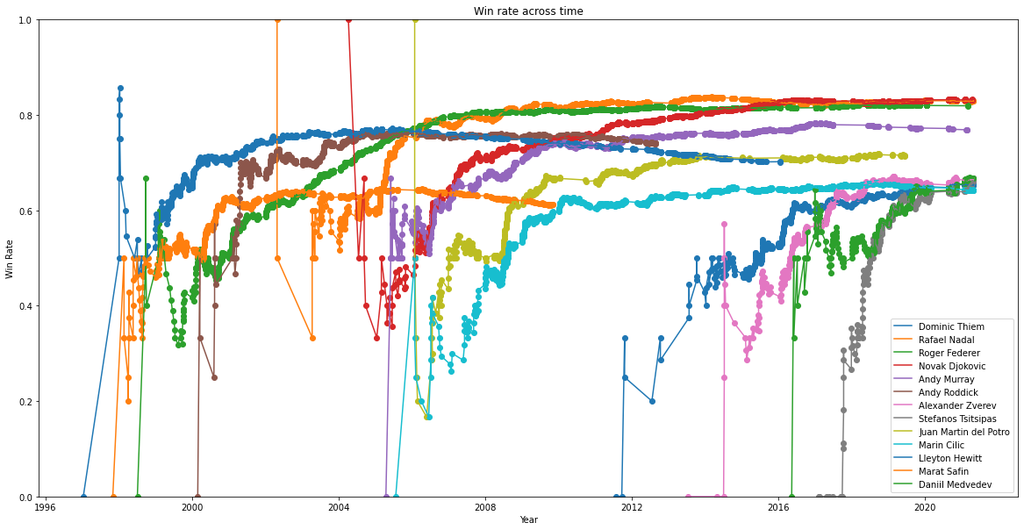

```python
# Creates figure
plt.figure(figsize=(20,10))
# Sets title and axis labels
plt.title('Win rate across time')
plt.xlabel('Year')
plt.ylabel('Win Rate')
plt.ylim((0,1))
# Plots a line per player
for i in range(13):
    plt.scatter(dfs[i]['date'], dfs[i]['win_rate'])
    plt.plot(dfs[i]['date'], dfs[i]['win_rate'], label=players[i])
# Displays the legend
plt.legend()
plt.show()
```

The above plot shows running win rate across time for each of the players. We can see that at the beginning of each player's career, the win rate line is erratic. This is expected because the formula used to calculate the running win rate is $\frac{\texttt{total wins}}{\texttt{total matches}}$. So for the earliest parts of these players' careers, there is a small number of matches. Therefore, each win/loss has a far greater impact on the win rate compared to those later on in their careers. As a temporary fix, we will plot after each player's 20th match.

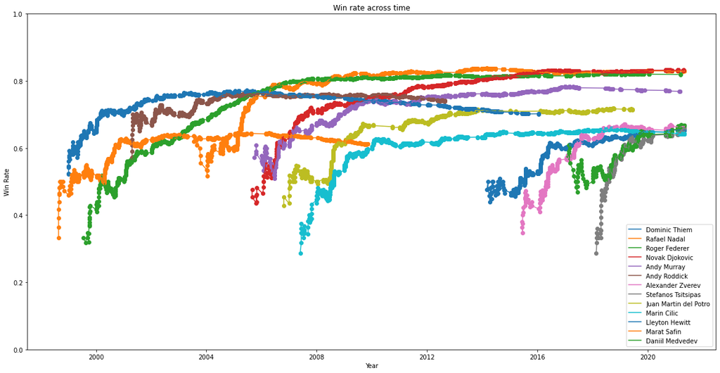

```python
# Creates figure
plt.figure(figsize=(20,10))
# Sets title and axis labels
plt.title('Win rate across time')
plt.xlabel('Year')
plt.ylabel('Win Rate')
plt.ylim((0,1))
# Plots a line per player
for i in range(13):
    plt.scatter(dfs[i]['date'][20:], dfs[i]['win_rate'][20:])
    plt.plot(dfs[i]['date'][20:], dfs[i]['win_rate'][20:], label=players[i])
# Displays the legend
plt.legend()
plt.show()
```

This looks much better after getting rid of the first 20 matches. We can see that this plot gives different possible insight compared to the cumulative wins plot. We see that Roger Federer, Rafael Nadal, and Novak Djokovic are much closer in this plot compared to the runaway first place that Federer had in the cumulative wins plot. Furthermore, we can see some subtle patterns that may be related to slumps in tennis. From about 2014-2017 we see a steady decline in Rafael Nadal's win rate. This indicates that he was not doing much winning in this period of time, and might be indicative of a slump. Historically, during this period of time, Nadal was experiencing what he called a "lack of confidence" and was in a self identified slump. Now, this is not to say that there is a correlation, and based on the above plot, we cannot see anything similar for Dominic Thiem. To really get a better grasp and understanding of this data and to discover what a slump is in tennis, we need to do some deeper analysis.

### Data Analysis

Something we can do to track how well a player is doing at a given time is look at a relative win rate. This is to say that rather than looking at win rate over a player's entire career, we can limit our window of matches to a limited number of matches. This way, we have a win rate that is based on much more recent matches as opposed to being cushioned (or weighed down) by all of the matches a player has played up until that point. By limiting our window of matches, we can see if a player is winning a higher percentage of matches relative to even a month prior or a month later. So the formula for this relative win rate would be $\frac{\texttt{wins during # of matches}}{\texttt{# of matches}}$ where "$\texttt{# of matches}$" is a fixed number of matches that we choose to be the size of the moving "window".

```python
# Set the number of matches to calc win rate over
window_size = 200
# Creates matrix to hold relative win rate
rel_wr_mat = []

# Loops over
for df in dfs:
    win_tots = np.array(df['c_win'])
    rel_wr = []
    for i in range((window_size - 1), win_tots.shape[0]):
        wr = (win_tots[i] - win_tots[i - (window_size - 1)]) / window_size
        rel_wr.append(wr)
    rel_wr_mat.append(rel_wr)
```

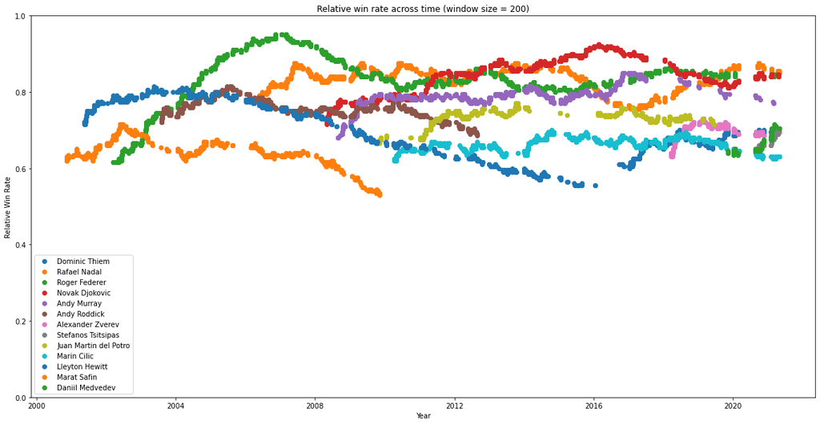

```python
# Creates figure
plt.figure(figsize=(20,10))
# Sets title and axis labels
plt.title('Relative win rate across time (window size = ' + str(window_size) + ')')
plt.xlabel('Year')
plt.ylabel('Relative Win Rate')
plt.ylim((0,1))
# Plots a line per player
for i in range(13):
    plt.scatter(dfs[i]['date'][window_size - 1:], rel_wr_mat[i], label=players[i])
# Displays the legend
plt.legend()
plt.show()
```

Here, we can see a much different picture when it comes to win rates. By looking at a 200 match window, we are only considering relatively recent matches, so there is much more fluxuation and variation as this relative win rate is much more indicative of how well the player is performing at the current moment. In other words, if a player goes on a hot streak and wins a lot of matches, this relative win rate is likely going to be higher than a normal win rate. Similarly, if a player goes on a losing streak (could be considered a slump) then the relative win rate will be much lower than the player's career win rate at that point in time. By only factoring in recent matches, we are able to see the rise in a player's success as well as the dips. Looking at the graph above, while it is a bit chaotic, we can see that in the careers of the big three (Federer, Nadal, and Djokovic), there are drastic dips for prolonged periods of time. Let's investigate this further.

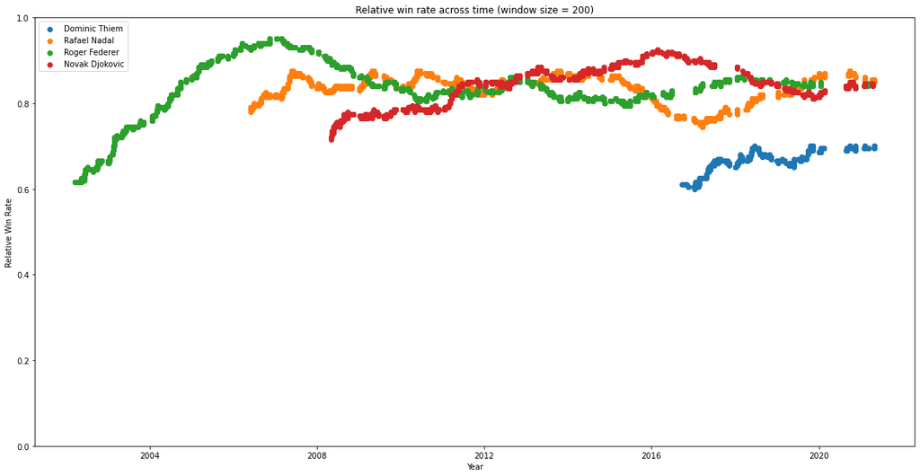

```python
# Creates figure
plt.figure(figsize=(20,10))
# Sets title and axis labels
plt.title('Relative win rate across time (window size = ' + str(window_size) + ')')
plt.xlabel('Year')
plt.ylabel('Relative Win Rate')
plt.ylim((0, 1))
# Plots a line per player
for i in [0,1,2,3]:
    plt.scatter(dfs[i]['date'][window_size - 1:], rel_wr_mat[i], label=players[i])
# Displays the legend
plt.legend()
plt.show()
```

The above graph shows the relative win rate of the big three and Dominic Thiem. On a 200 match window, we can see notable dips in win rate for Federer, Nadal, and Djokovic. Looking at Federer, there is a large decline starting at $\approx$2008 and lasting until $\approx$2011. Looking at what was happening at this time is interesting. Before 2008, Federer was dominating the tennis world (the relative and career win rate graphs both heavily point to this, with Federer achieving a relative win rate of up to $\approx$95%). So a dip in relative win rate may partially be attributed to him having a historic hot streak prior to 2008. As we can see, Federer's relative win rate drops to about 80%, which is still a very high win rate, and seems to be where the other members of the big three hover around for their careers. Federer experiences a dip in win rate again at the 2012 mark, and this time the win rate stays at $\approx$80% for about 5 years (until 2017). This prolonged period of time may be more indicative of a slump, as the narrative during this period of time was that Federer was not winning any Grand Slams (between Wimbledon 2012 and the Australian Open 2017, Federer won 0 Grand Slam titles). If we look at Nadal's relative win rate, we see a noticeable drop in win rate to below 75%, which occurred from $\approx$2014/2015 and lasted until 2017. For historical context, during this period of time, Nadal openly discussed how he was lacking confidence and was struggling on court. This context is important, because this could be far more indicative of a slump. For Djokovic, he experiences a dropping relative win rate from about 2016 to almost 2020. It should be noted that his win rate during this period of time starts at $\approx$93% and drops to $\approx$83%, so while it is a drop, it is a similar-ish case to that of Roger Federer. The 2015 season for Novak Djokovic is considered by many to be one of the most dominant seasons. He captured 3 Grand Slam titles that year while making the final of all 4, as well as winning a record 6 Masters 1000 titles during the season. He had a good year in 2016, however after coming off a 2015 historic season, a dip in relative win rate is somewhat expected (a case of a hot streak). However, for much of 2017 and 2018, Djokovic dealt with injuries as well as a case of just not playing well. We can see this period of time in the graph, where there is a plateau followed by a very steep drop from 2017 to 2018.

Looking at Dominic Thiem's graph, we do not see nearly as drastic of a drop in relative win rate (although there are smaller dips). For a player that is earlier in his career, this may play a factor, along with a miriade of other variables. Surprisingly enough, the biggest dip in his career is from what seems to be mid 2018 through to about mid 2019. If we look at the graph around today, there is a drop, however it is hard to see. Let's observe Thiem's graph alone to see if we can find any other details.

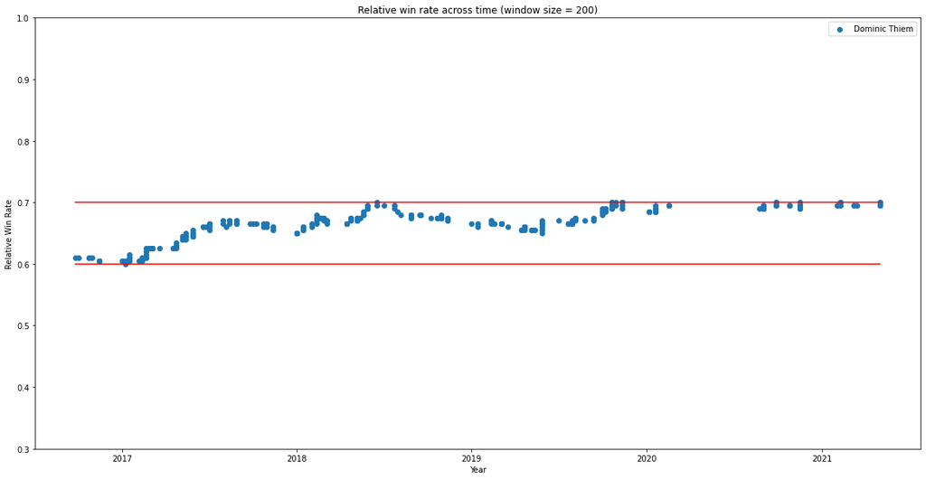

```python
# Creates figure
plt.figure(figsize=(20,10))
# Sets title and axis labels
plt.title('Relative win rate across time (window size = ' + str(window_size) + ')')
plt.xlabel('Year')
plt.ylabel('Relative Win Rate')
plt.ylim((0.3,1))
# Plots a line per player
for i in [0]:
    plt.scatter(dfs[i]['date'][window_size - 1:], rel_wr_mat[i], label=players[i])
    #plt.plot(dfs[i]['date'][window_size - 1:], rel_wr_mat[i], label=players[i])
    plt.plot(dfs[i]['date'][window_size - 1:], np.ones(len(rel_wr_mat[i])) * 0.7, color='red')
    plt.plot(dfs[i]['date'][window_size - 1:], np.ones(len(rel_wr_mat[i])) * 0.6, color='red')
# Displays the legend
plt.legend()
plt.show()
```

Looking specifically at Dominic Thiem's career track, we can see that there really does not seem to be much of a dip. Looking at other graphs on different scales seems to throw things off, however from the above graph, we can see that even Thiem's relative win rate seems to be steady, and is in fact seems to have a general trend of increasing (starting at $\approx$60% and recently being as high as $\approx$70%). This seems to be good news, as Thiem doesn't seem to be experiencing nearly as stark of a drop off in relative win percentage as the historic slumps of Federer, Nadal, or Djokovic, indicating that Thiem might not be in a slump.

The last thing we will look at for now is each player's win rate by career year. That is, we will look at each player's career and calculate the win rate in each individual year of their career. This can be useful later when building a model so that we can potentially fit a line to the data.

```python
# Creates array for each player
wr_per_year_mat = []
# Loops over each player's dataframe
for df in dfs:
    # Gets length of player's career (for active players the current years)
    num_years = df['year_career'].unique().shape[0]
    wr_per_year = []
    # Loops over each year
    for year in range(num_years):
        # Gets indices for current year
        tmp = np.where(df['year_career'] == year)[0]
        # Gets index of last match in current year
        curr = max(tmp)
        # If we are not in the first year, subtract wins/matches from previous years
        if year != 0:
            prev = min(tmp) - 1
            tot_wins = df['c_win'][curr] - df['c_win'][prev]
            tot_matches = (df['c_win'][curr] + df['c_loss'][curr]) - (df['c_win'][prev] + df['c_loss'][prev])
        else:
            tot_wins = df['c_win'][curr]
            tot_matches = df['c_win'][curr] + df['c_loss'][curr]
        # Calculate win rate for that year
        wr = tot_wins / tot_matches
        wr_per_year.append(wr)
    wr_per_year_mat.append(wr_per_year)
```

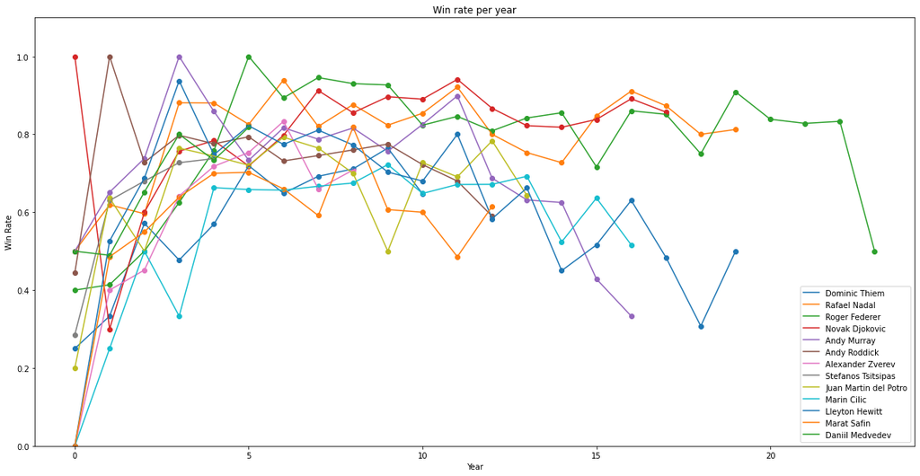

```python
# Creates figure
plt.figure(figsize=(20,10))
# Sets title and axis labels
plt.title('Win rate per year')
plt.xlabel('Year')
plt.ylabel('Win Rate')
plt.ylim((0,1.1))
# Plots a line/points per player
for i in range(13):
    plt.scatter(list(range(len(wr_per_year_mat[i]))), wr_per_year_mat[i])
    plt.plot(list(range(len(wr_per_year_mat[i]))), wr_per_year_mat[i], label=players[i])
# Displays the legend
plt.legend()
plt.show()
```

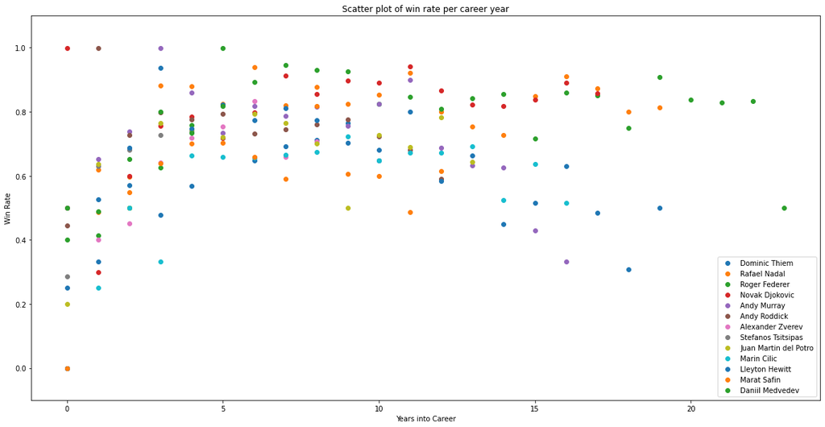

```python
# Creates figure
plt.figure(figsize=(20,10))
# Sets title and axis labels
plt.title('Scatter plot of win rate per career year')
plt.xlabel('Years into Career')
plt.ylabel('Win Rate')
plt.ylim((-0.1,1.1))
# Creates scatterplot for each player
for i in range(13):
    plt.scatter(list(range(len(wr_per_year_mat[i]))), wr_per_year_mat[i], label=players[i])
# Displays the legend
plt.legend()
plt.show()
```

From looking at this data, we can see a general trend. As players progress through their careers, the win rate seems to approach a certain win rate. There is an increasing amount of noise past year $\approx$11, and this is due to the fact that we are looking at players whose careers have ended. Despite this, we see a general trend of increase in the beginning $\approx$5 years of each player's career, and then a plateau or small decline. Since Federer, Nadal, and Djokovic are the three most winning men's players, it is highly likely that they are outliers in this data. Let's plot the win rate by career year excluding them to see if we see a more uniform trend.

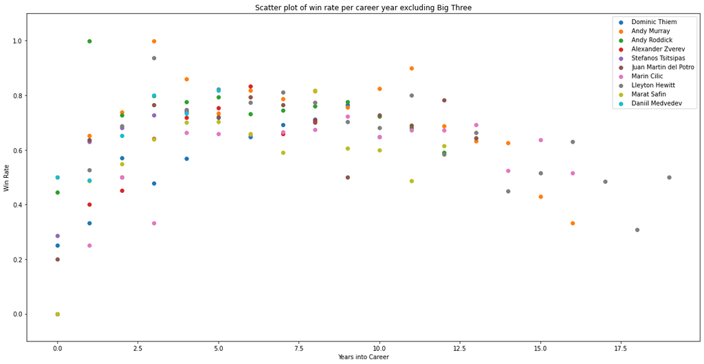

```python
# Creates figure
plt.figure(figsize=(20,10))
# Sets title and axis labels
plt.title('Scatter plot of win rate per career year excluding Big Three')
plt.xlabel('Years into Career')
plt.ylabel('Win Rate')
plt.ylim((-0.1,1.1))
# Creates scatterplot for each player
for i in [0,4,5,6,7,8,9,10,11,12]:
    plt.scatter(list(range(len(wr_per_year_mat[i]))), wr_per_year_mat[i], label=players[i])
# Displays the legend
plt.legend()
plt.show()
```

Aha! We seem to have a much more uniform distribution for each year after getting rid of Federer, Nadal, and Djokovic. This will be useful as we will now begin fitting lines and models to our data.

## Hypothesis Testing/Modeling

We want to now take the data that we have a fit various models to it so that we can use the data to answer the question about slumps in men's tennis.

```python
# Empty array for x and y points
xs = []
ys = []
# Loops over the win rate per year matrix
# This unwraps the 2d array wr_per_year_mat into two arrays xs and ys
for arr in wr_per_year_mat:
    for i in range(len(arr)):
        if i <= 19:
            xs.append(i)
            ys.append(arr[i])
# Converts to numpy arrays
xs = np.asarray(xs)
ys = np.asarray(ys)
```

```python
# Empty array for x and y points
xs2 = []
ys2 = []
# Loops over the win rate per year matrix
# This unwraps the 2d array wr_per_year_mat into two arrays xs and ys
# Excludes the points for Federer, Nadal, and Djokovic
for i in [0,4,5,6,7,8,9,10,11,12]:
    arr = wr_per_year_mat[i]
    for j in range(len(arr)):
        if j <= 16:
            xs2.append(j)
            ys2.append(arr[j])
# Converts to numpy arrays
xs2 = np.asarray(xs2)
ys2 = np.asarray(ys2)
```

```python
# Formats X matrix for linear regression and fits the line
X = np.stack([xs2**2, xs2], axis=1)
reg = LinearRegression().fit(X, ys2)
```

```python
reg.coef_
```

```
array([-0.00596192,  0.09587245])
```

```python
reg.intercept_
```

```
0.3847527099815178
```

We can see that the regression line is $y=-0.006x^2+0.0959x+0.385$, where $y$ is the win rate and $x$ is the career year.

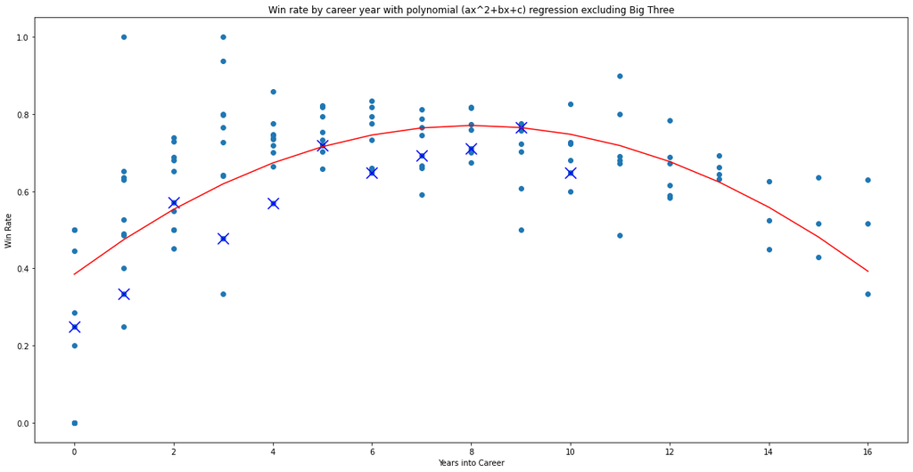

```python
# Plots win rate per year and the parabolic curve
plt.figure(figsize=(20,10))
plt.title('Win rate by career year with polynomial (ax^2+bx+c) regression excluding Big Three')
plt.xlabel('Years into Career')
plt.ylabel('Win Rate')
plt.scatter(xs2, ys2)
plt.scatter(list(range(11)), wr_per_year_mat[0], s = 200, marker = 'x', color = 'b')
plt.plot(sorted(xs2), reg.predict(X)[np.argsort(xs2[:])], 'r-')
```

```python
# Formats the parabolic X matrix and fits the regression line
X2 = np.stack([xs**2, xs], axis=1)
reg2 = LinearRegression().fit(X2, ys)
```

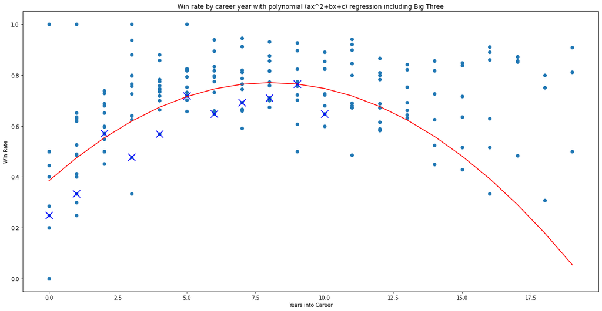

```python
# Plots win rate per year and the parabolic curve
plt.figure(figsize=(20,10))
plt.title('Win rate by career year with polynomial (ax^2+bx+c) regression including Big Three')
plt.xlabel('Years into Career')
plt.ylabel('Win Rate')
plt.scatter(xs, ys)
plt.scatter(list(range(11)), wr_per_year_mat[0], s = 200, marker = 'x', color = 'b')
plt.plot(sorted(xs), reg.predict(X2)[np.argsort(xs[:])], 'r-')
```

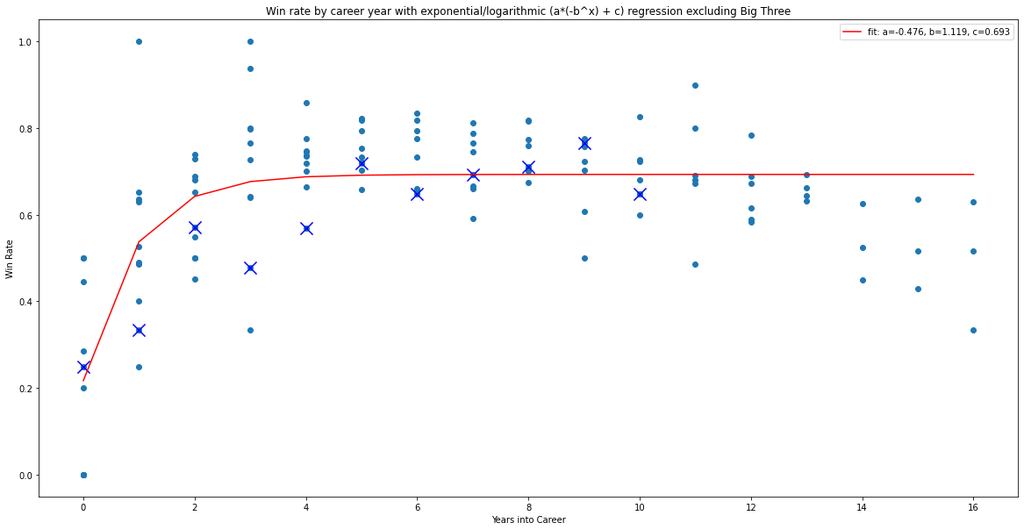

```python
# Defines exponential function to be used as the 'regression' curve
def func(x, a, b, c):
    return a * np.exp(-b * x) + c
# Fits the curve
popt, pcov = curve_fit(func, xs2, ys2)
# Plots win rate per year and displays curve and marks Thiem's points
plt.figure(figsize=(20,10))
plt.scatter(xs2, ys2)
plt.title('Win rate by career year with exponential/logarithmic (a*(-b^x) + c) regression excluding Big Three')
plt.xlabel('Years into Career')
plt.ylabel('Win Rate')
plt.scatter(list(range(11)), wr_per_year_mat[0], s = 200, marker = 'x', color = 'b')
plt.plot(sorted(xs2), func(np.array(sorted(xs2)), *popt), 'r-', label='fit: a=%5.3f, b=%5.3f, c=%5.3f' % tuple(popt))
plt.legend()
plt.show()
```

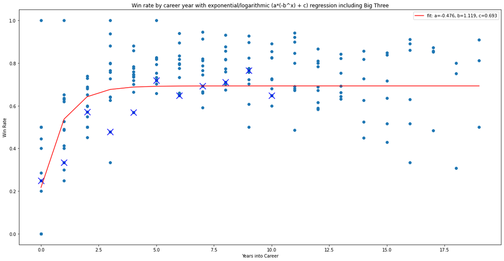

```python
# Uses Scipy's curve_fit to fit a logarithmic function to the data
popt, pcov = curve_fit(func, xs2, ys2)
# Plots the points for win rate per year and the log curve and marks Thiem's points
plt.figure(figsize=(20,10))
plt.title('Win rate by career year with exponential/logarithmic (a*(-b^x) + c) regression including Big Three')
plt.xlabel('Years into Career')
plt.ylabel('Win Rate')
plt.scatter(xs, ys)
plt.scatter(list(range(11)), wr_per_year_mat[0], s = 200, marker = 'x', color = 'b')
plt.plot(sorted(xs), func(np.array(sorted(xs)), *popt), 'r-', label='fit: a=%5.3f, b=%5.3f, c=%5.3f' % tuple(popt))
plt.legend()
plt.show()
```

From the above plots with their respective regression lines, we can see that the polynomial fit ($ax^2+bx+c$) is better when excluding the Big Three (Federer, Nadal, and Djokovic). However, the exponential/logarithmic fit ($a\cdot e^{-b*x}+c$) is better when we include the Big Three. Note that the large blue X's mark Dominic Thiem's win rate during that particular year. To see how well these fit, let's look at the residual plot.

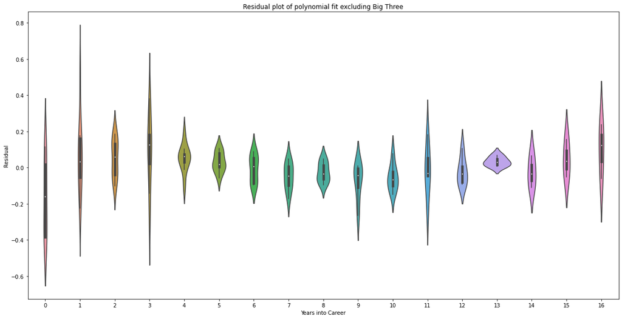

```python
# Calculates residuals
resid1 = ys2 - reg.predict(X)
# Plots the violinplot of residuals
plt.figure(figsize =(20,10))
plt.title('Residual plot of polynomial fit excluding Big Three')
plt.xlabel('Years into Career')
plt.ylabel('Residual')
seaborn.violinplot(x=xs2, y=resid1)
```

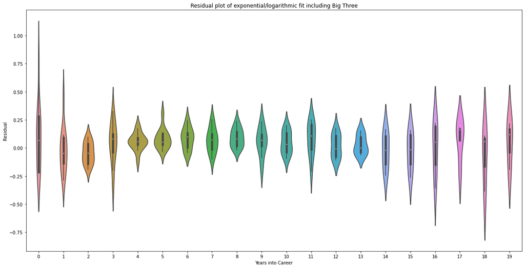

```python
# Calculates residuals
resid2 = ys - func(np.array(xs), *popt)
# Plots the violinplot of residuals
plt.figure(figsize =(20,10))
plt.title('Residual plot of exponential/logarithmic fit including Big Three')
plt.xlabel('Years into Career')
plt.ylabel('Residual')
seaborn.violinplot(x=xs, y=resid2)
```

In each of these residual plots, we can see that the mean (represented by the small white dot in the center of each blob) is around zero.

Let's first discuss the first residual plot. The binomial function has more violins that are not centered at zero, which suggests that a binomial function is not actually the best fit for the data. For the first residual plot, the violin at year 2 seems to be bimodal, which is another concern for how well the fit is for the data. The variance is not constant between each violin, which is indicated by the extrema not being the same for a number of violins. This being said, the rest of the data seems acceptable for this regression line.

The second residual plot actually shows even better results, which is a positive because this includes the data for the Big Three. We can see that the means are all close to 0 for each violin, and each violin seems to be normally distributed (unimodal and not much skew). There is an issue of far greater variance in years 0, 1, 16, 17, 18, and 19 compared to the other years, since the extrema for these years are much further away from zero than the other years. However, for the most part, this residual plot seems to indicate that the exponential curve fits this data relatively well.

Interestingly enough, if we look at the plots from above and look at the X's representing Dominic Thiem's win rates per career year, we can see that a different sort of relationship seems to exist. Let's plot a simple linear regression for Thiem's yearly win rate and make some observations.

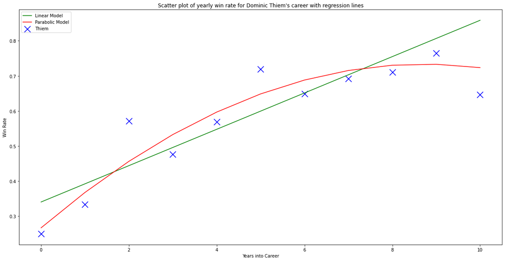

```python
# Creates list for career year
xs_thiem = np.array(list(range(10)))
# Reshapes to be used in regression
X_thiem_l = xs_thiem.reshape((-1,1))
X_thiem_p = np.stack([xs_thiem**2, xs_thiem], axis=1)
# Fits to the win rate per years into career for Thiem
y_thiem = np.array(wr_per_year_mat[0][0:10])
lm = LinearRegression().fit(X_thiem_l, y_thiem)
pm = LinearRegression().fit(X_thiem_p, y_thiem)
# Gets X matrix for predictions
X_pred_l = np.array(list(range(11))).reshape((-1,1))
X_pred_p = np.stack([np.array(list(range(11)))**2, np.array(list(range(11)))], axis=1)
# Plots win rate per year along with regression lines
plt.figure(figsize=(20,10))
plt.title('Scatter plot of yearly win rate for Dominic Thiem\'s career with regression lines')
plt.xlabel('Years into Career')
plt.ylabel('Win Rate')
plt.scatter(list(range(11)), wr_per_year_mat[0], s = 200, marker = 'x', color = 'b', label='Thiem')
plt.plot(np.array(list(range(11))), lm.predict(X_pred_l), 'g', label='Linear Model')
plt.plot(np.array(list(range(11))), pm.predict(X_pred_p), 'r', label='Parabolic Model')
plt.legend()
```

```python
# Gets the error for the linear and parabolic models
lin_err = sklearn.metrics.mean_squared_error(y_true=y_thiem, y_pred=lm.predict(X_thiem_l))
par_err = sklearn.metrics.mean_squared_error(y_true=y_thiem, y_pred=-pm.predict(X_thiem_p))
lin_err, par_err
```

```
(0.0046897588987576825, 1.415947091596855)
```

```python
# Prints out predicted win pct, loss pct, and p-value
lm.predict([[10]]), 1 - lm.predict([[10]]), (lm.predict([[10]])**8) * (1 - lm.predict([[10]]))**4
```

```
(array([0.8586085]), array([0.1413915]), array([0.00011805]))
```

```python
# Prints out predicted win pct, loss pct, and p-value
pm.predict([[100,10]]), 1 - pm.predict([[100,10]]), (pm.predict([[100,10]])**8) * (1 - pm.predict([[100,10]]))**4
```

```
(array([0.72366283]), array([0.27633717]), array([0.00043858]))
```

```python
# Prints win pct, loss pct for Thiem's 2021 season
wr_per_year_mat[0][9], 1 - wr_per_year_mat[0][9]
```

```
(0.7647058823529411, 0.23529411764705888)
```

```python
# Prints p-value as well as number of consecutive losses needed to be significant
(wr_per_year_mat[0][9]**8) * (1 - wr_per_year_mat[0][9])**4, np.log(0.05) / np.log(1 - wr_per_year_mat[0][9])
```

```
(0.0003584261829224477, 2.0704215708571048)
```

## Conclusion

A slightly pessemistic observation is to look at the career trajectories of the other players. For players such as Murray, Roddick, and Hewwitt, after year 10 of their respective careers, they experienced a decline in win rate as they continued to age. However, it is also very important to consider that we live in an age of far advanced sports medicine and fitness. Many of the fitness problems that players like Murray, Roddick, and Hewwitt have had to deal with in their careers is likely to be less of a factor when it comes to Dominic Thiem. This is exemplified by the careers of the Big Three, who even at ages 39 (Federer), 34 (Nadal), and 33 (Djokovic), have not experienced quite the decline in win rate as these players. Although it is a far stretch to say Thiem is on the same path as these 3 legends, it is important to realize that the role age plays in a player's career trajectory is vastly different today compared to even a decade ago.

The key in understanding and contextualizing the results of this tutorial is the definition of a slump. Is a slump **any** dip in win rate? Is it a **prolonged** dip in win rate? If so, how long must the duration for the slump be? How far must the win rate drop in order to be considered a slump? These are questions that were not answered through the hypothesis tests that were conducted in this project. To answer some of these questions, we would have to find a slightly different statistic to measure (something such as a more controlled relative win rate). We would need to optimize the window size so that we are looking at recent performances, but not falling into traps of having small sample sizes (leading to extremely high variance).

To put it simply, Thiem **is** experiencing a dip in win rate, indicating **some** type of slump. However, due to the small sample size of matches in 2021, and more importantly, the graphs of relative win rate, Thiem does **not** seem to be experiencing any type of prolonged slump, or a longer period of lower win rate.

As a Dominic Thiem fan, I really am rooting for a turnaround in this season. The hypothesis tests did show that he was in a slump, and I am really rooting that he can turn around and make sure it doesn't become a prolonged slump. Especially after having a stellar year in 2020 despite the pandemic, after having won his first Grand Slam at the U.S. Open in New York, I wish nothing but the best for Thiem this season and for the rest of his career.

If you would like to read a bit about statistical slumps in sports, you can click [this link](https://freakonomics.com/2009/08/26/statistical-slumps/).

If you would like to read about Dominic Thiem's 2020 U.S. Open run, you can click [this link](https://www.nytimes.com/2020/09/13/sports/tennis/us-open-mens-final-zverev-thiem.html).

A link to another great article breaking down the 2019 Australian Open can be found [here](https://towardsdatascience.com/just-how-good-is-novak-djokovic-401ce07c7ef3).

Tennis, for a sport that is played internationally and fairly well-known, has a great need for in-depth data, as there really isn't much quality data out there aside from [Jeff Sackmann's data](https://github.com/JeffSackmann/tennis_atp). As the tennis world grows, more in-depth and interesting data will surely emerge, pushing the game to a new level.

Thank you for taking the time to read through this analysis of Dominic Thiem's current performances and men's tennis win rates.